# Bayesian & Probabilistic Models

## Overview

1. Using Bayes Rule
2. A simple model
3. Estimation
4. Why Bayes?
5. Some more models
6. Probabilistic modeling (if we have time)

## Beginning with a common example

- A rare disease only affects 0.5% of the population
- New test is made that always detects disease when tested on diseased people
- However, it falsely tests positive 5% of the time in healthy people

**What is the probability a person has the disease when tested positive?**

## Beginning with a common example

- We incorrectly diagnose 5% of healthy people as diseased
- So some might say 95% of people who test positive are diseased

**95% is far too high - we need to include prior information about our rates**  
\[ P(\cdot) = \frac{\text{# diseased who tested positive}}{\text{# people who tested positive}} \]

## Need to know probability of diseased given a positive test result

\[ P(diseased|positive) = \frac{P(positive|diseased)P(diseased)}{P(positive)} \]  
\(P(diseased) = 0.005\)

\(P(healthy) = 0.995\)

\(P(positive|diseased) = 1\)

\(P(positive|healthy) = 0.05\)

## Need to know probability of diseased given a positive test result

\[ P(dis.|pos.) = \frac{P(pos.|dis.)P(dis.)}{P(pos.|dis.)P(dis.)+ P(pos.|healthy)P(healthy)} \]  
\(P(diseased) = 0.005\)

\(P(healthy) = 0.995\)

\(P(positive|diseased) = 1\)

\(P(positive|healthy) = 0.05\)

## Need to know probability of diseased given a positive test result

\[ P(diseased|positive) = \frac{1*0.005}{1*0.005+ 0.05*0.995} \]  
\(P(diseased) = 0.005\)

\(P(healthy) = 0.995\)

\(P(positive|diseased) = 1\)

\(P(positive|healthy) = 0.05\)

## Need to know probability of diseased given a positive test result

\[ P(diseased|positive) \approx 0.0913 \]  
**Only about 9%**  
In 1000 people, ~50 healthy people would be diagnosed while there'd be only 5 actual diseased people

## Bayes rule is the foundation of many different models

\[ P(\theta|Y) = \frac{P(Y|\theta)P(\theta)}{P(Y)} \]

- In the previous example, we had almost perfect information
- When we don't have perfect information, we need to use distributions to describe what we do know
- Instead of thinking the above as exact probabilities, now think of them as distributions

## Bayes rule is the foundation of many different models

\[ P(\theta|Y) = \frac{P(Y|\theta)P(\theta)}{P(Y)} \]

- \(P(Y|\theta)\) is our **likelihood** of the data
- \(P(\theta)\) is our **prior** information
- \(P(\theta|Y)\) is our **posterior**, or distribution of estimates

These are described as probability distributions rather than single probabilities

## Using Bayesian inference as an example

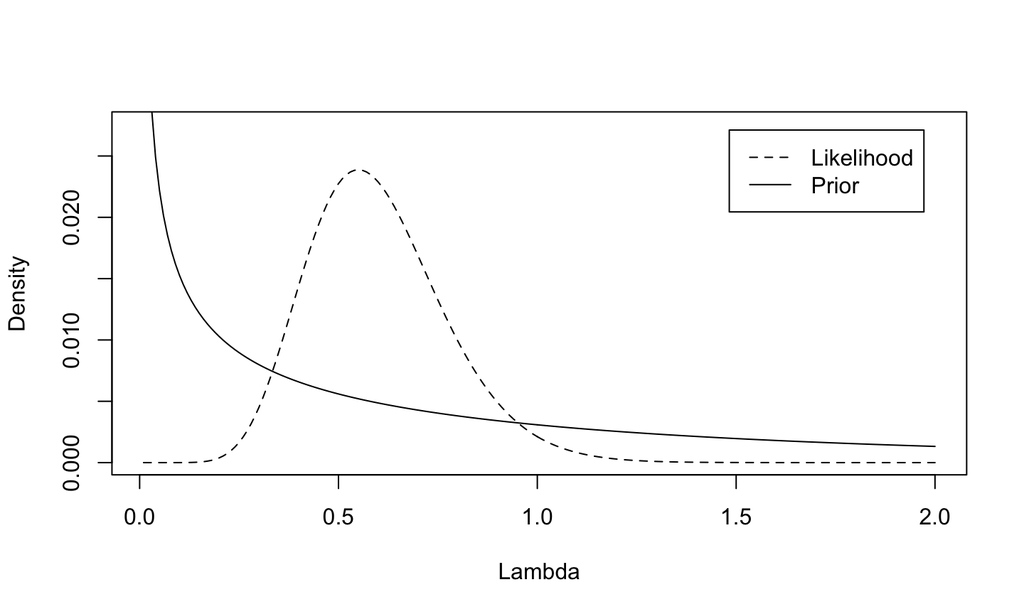

## Using Bayesian inference as an example

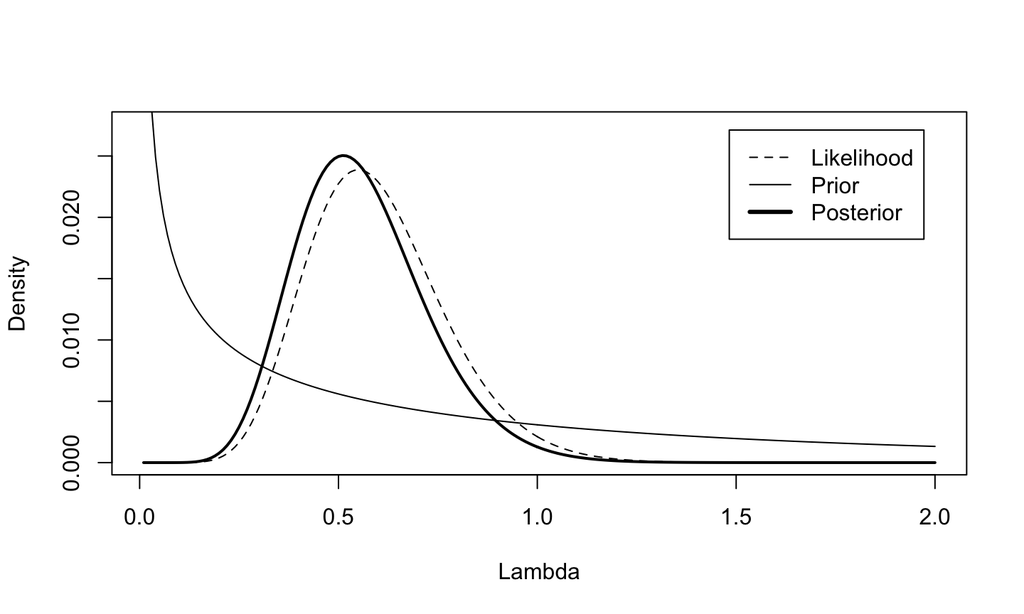

## Using Bayesian inference as an example

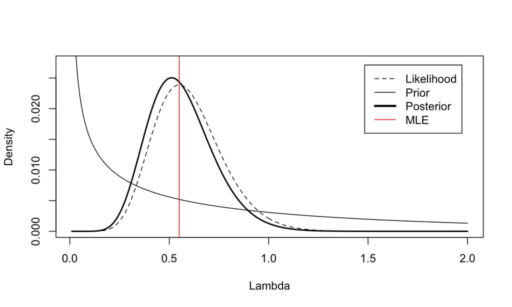

## So what just happened

- The maximum likelihood estimate is a way to get a parameter value by just looking at the data
- In this case it would be \(11/20\) or \(0.55\)

\[ \theta = \text{arg max }{P(Y|\theta)} \]

\[ \theta = \text{arg max }{L(\theta, Y)} \]  
This is just a "point estimate"" (often times the mean)

## Is there a "Bayesian MLE"?

- Well, kind of: the maximum a posteriori (MAP) estimate

\[ \theta = \text{arg max }P(Y|\theta)P(\theta) \]

- The value of theta that has the maximum probability within our posterior distribution
- This takes prior information into account and isn't a "point calculation"

## Using Bayesian inference as an example

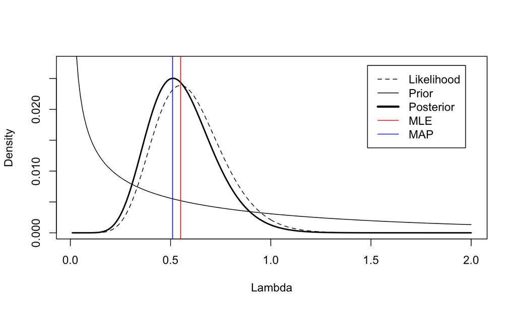

## A note on priors

- In the previous example, we used a relatively "uninformative prior"
- This means we just chose a distribution that would have little influence
- This is a very common approach, with the uniform or normals being used
- You can choose an informative prior too

## Why should we care about Bayesian models?

- Results are very interpretable & don't rely on p-values :)
- Incorporates more information
- Highly flexible
- Historically less biased for high-dimensional problems

## What the pitfalls of Bayesian analysis?

- Computationally expensive (for many common models)
- You have to incorporate more information

## A lot has been covered so far, but there's a lot more

- Paramter estimation via sampling - think MCMC
- Classification & Naive Bayes
- Bayesian networks